# Postup stažení, analýzy a přípravy dat a modelování témat časopisu *Rozpravy* České Akademie v letech 1890-1910

### 3.2 UDPipe 2

Zkrácené textové soubory jsou následně obohaceny pomocí nástroje UDPipe2, k čemuž slouží skript `/data_preparation/send_to_udpipe.R`.

K obohacení je použita webová služba LINDAT UDPipe REST Service[^2]. Konkrétně model *czech-pdt-ud-2.12-230707*, který zajistí pro každé slovo z textového přepisu tokenizaci, lemmatizaci a identifikaci slovního druhu.

Obdobně jako při odstraňování krátkých slov je potřeba nejprve načíst data ze pracovního adresáře:

```r
current_working_directory <- getwd() # nastavený pracovní adresář
folder_path <- file.path(current_working_directory, "rozpravy_trida_2") # cesta ke složce s TXT soubory
```

Postupně jsou opět zpracovány všechny `.txt` soubory v nastavené složky, které mají ve svém názvu prefix `PREPARED_TEXT`. O jejich zpracování se postará funkce `processAllTxtFiles()`, která pro každý soubor postupně spustí funkci `enrichFile(file_name)`. Tato funkce zajistí:

- sestavení příkazu pro nástroj *curl* (`setCurl(filename)`) (funkci mohou vadit spojovníky, pomlčky a mezery mezi nimi v názvu souborů, doporučuje se takové názvy změnit)
- odeslání příkazu na LINDAT UDPipe REST Service a vyčkání na odpověď (`postRequest(curl_command)`)
- uložení získané odpovědi ve formátu CoNLLU (`saveConllu(response_content, file_name)`) - pro každý svazek je uložen jeden JSON soubor s prefixem `CoNLLU_`
- vyfiltrování podstatných jmen (jejich lemmat) ze získaných dat a jejich uložení,

K filtrování je použita funkce `getNouns(df, file_name)`:

```r
getNouns <- function(df, file_name){
  base_file_name <- basename(file_name)
  filtered_df <- df %>% filter(upos == "NOUN") # vyhledání pouze podstatných jmen
  noun_tokens <- filtered_df$lemma # pouze sloupec obsahující lemma
  # [...]
}
```

Získaná podstatná jména (`noun_tokens`) jsou uložena do `.txt` souborů s prefixem `NOUNS_`, ze kterých bude vytvořena matice dokument-slovo, sloužící jako vstup pro tematické modelování.

Protože v rámci procesu obohacení nástrojem UDPipe2 mohly být některé rozsáhlejší chyby vzniklé procesem OCR identifikovány chybně jako podstatná jména a zkrácena na jedno nebo dvouznakovou lemmu, byl nad vzniklými soubory s prefixem `NOUN_` znovu spuštěn skript `data_preparation/remove_short_words.R`. Aby proběhl správně, je ovšem potřeba změnit ve funkci `processAllTxtFiles()` prefix souborů a nastavit nový prefix pro výstupy. Soubory připravené pro proces tematického modelování nesou prefix `LDA_PREPARED_`

```r
# Změna prefixu z "TEXT" na "NOUN" ve funci processAllTxtFiles:

processAllTxtFiles <- function() {
  txt_files <- list.files(path = folder_path, pattern = "^NOUN.*\\.txt$") # seznam TXT souborů začínajících na "NOUN" ve složce
  # [...]
}

# Změna prefixu ukládaných souborů z "PREPARED" na "LDA_PREPARED" ve funkci prepare_data:
prepare_data <- function(full_file_path){
  text <- readLines(full_file_path) # čte věty z TXT souboru
  processed_text <- sapply(text, remove_short_words) # aplikuje funkci remove_short_words na každý řádek

  # Uložení do nového txt
  base_file_name <- basename(full_file_path)
  txt_file_name <- paste0("LDA_PREPARED_",base_file_name,".txt") # název souboru

  #[...]
}
```

## 4. Modelování témat

K modelování témat je používána metoda LDA. Celý proces včetně pojmenování vizualizace témat je k dispozici v souboru `/topic_model/LDA.Rmd`.

Opět je potřeba nejprve načíst soubory, se kterými bude model pracovat - předpokládá se jejich přesunutí do složky `/topic_model/data/`. Předpokládá se také, že do stejné složky, kde je soubor `LDA.Rmd` bude přesunut soubor `combined_issues_publication_year.json`.

```r
current_working_directory <- getwd() # nastavený pracovní adresář, předpokládá se adresář, kde je uložen tento script
relative_path_to_data <- "/data/*.txt" # podadresář se soubory
full_path <- paste0(current_working_directory,relative_path_to_data) # celá cesta k souborům

library(quanteda)
corpus <- corpus(readtext(full_path)) # načtení ve formě corpusu knihovny quanteda
```

Následně je potřeba data ze souborů rozložit na jednotlivé tokeny a vytvořit matici dokument-slovo (*documet-term matrix*). K načtení a manipulaci s daty se používá knihovna `quanteda`.

V rámci transformace do matice je možné odstranit z korpusu tzv. stop slova.

```r
# slova objevující se napříč všemi *Rozpravami* (zanedbatelný vliv na témata)
stop_CAVU <- c("akademie", "strana", "rozprava", "obsah", "fig", "tab", "pag", "hodina", "metr", "pozorování", "maximum", "den", "rok", "datum", "milimetr", "vel", "průměr", "minimum", "maximum", "stupeň", "leden", "únor", "březen", "duben", "květen", "červen", "červenec", "srpen", "září", "říjen", "listopad", "prosinec")

# nevýznamová slova a znaky v korpusu
stop_nonsense <- c("wsw", "nnw", "ssw", "wnw", "ene", "sse", "eše", "nne", "»", "«", "^", "srv", "srv", "ccm", "dod", "vyn", "tim", "vin", "kol", "ott", "oti", "jah", "upd", "rkp", "srvn", "stsl", "ghm", "srva", "pis", "cxo", "mgh")

# rozdělení na tokeny pro quantida
tokens <- tokens(corpus) %>%
  tokens_remove(c(stop_CAVU,stop_nonsense))

# matice dokument-slovo
dfm <- dfm(tokens)
```

K procesu LDA je využita knihovna `topicmodels`. Ta pracuje se specificky strukturovanou maticí dokument-slovo, je proto potřeba výše vytvořenou matici do této podoby převést.

```r
library(topicmodels)
dtm <- convert(dfm, to = "topicmodels")
```

Spuštění LDA si vyžaduje stanovit proměnnou `k`, která určí, kolik témat se má v korpusu identifikovat. Dále je možné nastavit hodnotu `alpha` - čím je vyšší, tím větší množství témat se může objevovat v jednom dokumentu. V našem případě je nastavena na `0.1`, neboť předpokládáme, že jedno číslo *Rozprav* se pravděpodobně věnovalo jednomu tématu. Hodnoty dalších parametrů jsou ponechány ve výchozím nastavení[^3], počet iterací Gibbsova vzorkování je v takovém případě 2000.

Dále je vhodné nastavit také funkci set.seed, která se používá k vytváření reprodukovatelných výsledků v případech, kdy se vytváří proměnné, které nabývají náhodných hodnot. Zaručuje se tak, že při každém spuštění kódu budou vytvořeny stejné náhodné hodnoty.

```r
set.seed(1234)
topic_model <- LDA(dtm, method = "Gibbs", k = 35,  control = list(alpha = 0.1))
topic_model
```

### 4.1 Matice *slovo-téma* (*word-topic matrix*)

LDA vytvoří matici *slovo-téma*, ve které je u každého slova z korpusu uvedeno s jakou pravděpodobností bylo vygenerováno z jakého tématu. Tato pravděpodobnost je označena jako `beta`. Model témata nijak nepojmenuje, označena jsou pouze čísly.

```r
word_topics <- tidy(topic_model, matrix="beta")
word_topics
```

```
## # A tibble: 4,668,755 × 3
##    topic term            beta
##    <int> <chr>          <dbl>
##  1     1 rejstřík 0.00000160
##  2     2 rejstřík 0.00000115
##  3     3 rejstřík 0.000237
##  4     4 rejstřík 0.00000155
##  5     5 rejstřík 0.00000296
##  6     6 rejstřík 0.00000114
##  7     7 rejstřík 0.000160
##  8     8 rejstřík 0.000000951
##  9     9 rejstřík 0.0000630
## 10    10 rejstřík 0.00000366
## # ℹ 4,668,745 more rows
```

Pro každé téma je možné zobrazit stanovený počet slov, která se v něm vyskytují s nejvyšší frekvencí:

```r
topic_number <- 8 # příklad pro téma č. 8

word_topic_posterior <- posterior(topic_model)$terms[topic_number, ]
top_words_for_topicX <- head(sort(word_topic_posterior, decreasing = T), n=50)
head(top_words_for_topicX)
```

```
##       buňka       jádro       hmota      vlákno       útvar    bakterie
## 0.051016457 0.039152165 0.016222778 0.011713015 0.009382020 0.008963392
```

Nejfrekventovanější slova tématu je také možné zobrazit jako wordcloud:

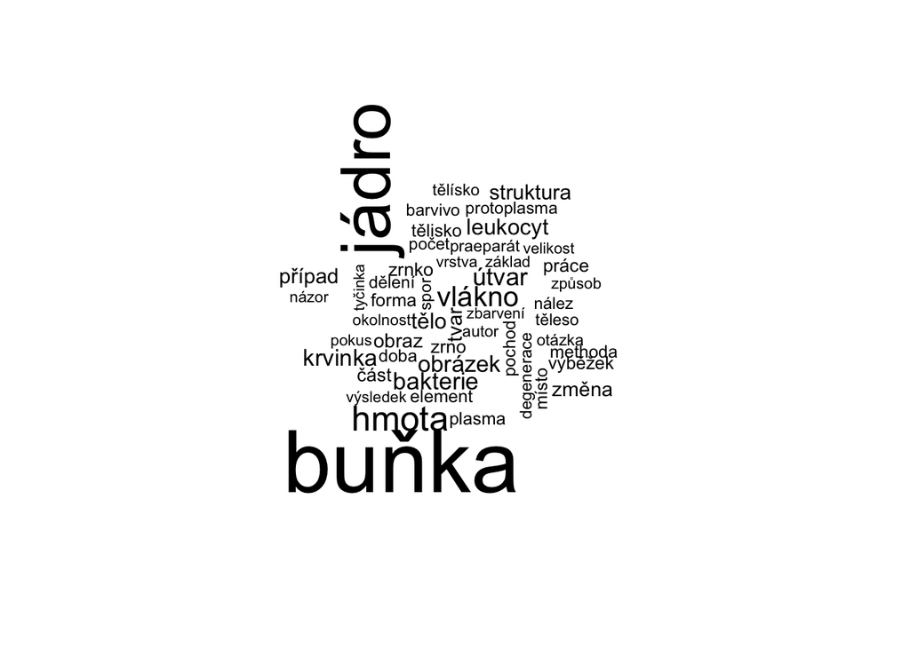

```r
wordcloud(names(top_words_for_topicX), top_words_for_topicX)
```

### 2.2 Matice *dokument-téma* (*documet-topic matrix*)

Druhým výstupem LDA je matice popisující pravděpodobnost příslušnosti dokumentu ke konkrétnímu tématu určená proměnnou `gamma`.

LDA přiřadí každému slovu v dokumentu téma. Čím více slov v dokumentu je přiřazeno k jednomu tématu, tím větší hodnotu má proměnná `gamma` a tím spíš pojednává dokument o daném tématu. `gamma` tedy udává odhadovanou proporci slov v dokumentu, která byla vygenerována z konkrétního tématu.

```r
topic_model_documents <- tidy(topic_model, matrix = "gamma")
topic_model_documents

document_to_topic <- topic_model_documents %>%
  group_by(document) %>%
  slice_max(gamma) %>%
  ungroup()
```

Také je možné vyfiltrovat všechny dokumenty, které patří k vybranému tématu:

```r
topic_number <- 8 # vybrané téma
document_topic_filtr <- filter(document_to_topic, document_to_topic$topic == topic_number)
document_topic_filtr
```

Analýza vzniklého modelu a jeho vizualizace jsou dostupné v souboru `/topic_model/LDA.Rmd`.

[^1]: použita byla verze R 4.3.2 (2023-10-31 ucrt) a aplikace RStudio verze 2023.09.1 Build 494
[^2]: https://lindat.mff.cuni.cz/services/udpipe/
[^3]: https://cran.r-project.org/web/packages/topicmodels/topicmodels.pdf